# Bootstrapping

Applied Machine Learning in Economics

As you can tell from the video, this lecture will be shorter. Because bootstrapping is a useful tool that is genius in its simplicity, we will manually do it. Another look underneath the hood. We will do the usual coefficient bootstrapping and a new technique: AB testing.

# 1 Coefficient Bootstrapping

Time for our preliminary setup:

```r
set.seed(490) # Why do we need to set the seed?
library(tidyverse)
ahs = read.csv('C:/Users/johnj/Documents/Data/Applied ML ECON490/Lecture Data/lecture data continuous.csv')
```

Suppose we are interested in the correlation between house values and the number of baths. We want to make sure we include other variables to control for other characteristics of the house. This produces the conditional correlation of the number of baths in a house.

We are also going to manually save our data. There are two ways we can do this. The first is to create a `NULL` object and bind coefficients to it. The second is to generate an complete `matrix` or `data.frame` to overwrite elements. The second is computationally more efficient due to the fact that it doesn’t have to effectively create a new object every iteration. Let’s do that.

```r
# Number of iterations
n = 500

# Creating our object to hold our results
vrbls = lm(log(value) ~ log(cost):hoa + npeople + log(hinc) + beds + baths + log(eqvval) + lotsize + yos + condo + garage + I(bld == 'Mobile Home') + poly(math, 2) - hoa, data = ahs) %>%
  coef %>%
  names

hold = matrix(NaN, ncol = length(vrbls), nrow = n)

index = 1:n
for(i in 1:n){
  hold[i, ] = lm(log(value) ~ log(cost):hoa + npeople + log(hinc) + beds + baths + log(eqvval) + lotsize + yos + condo + garage + I(bld == 'Mobile Home') + poly(math, 2) - hoa, data = ahs, subset = sample(index, n, replace = TRUE)) %>%
    coef
}
```

So, lets create some summary statistics and a pretty plot.

```r
# Which column was the baths variable again?
grep('baths', vrbls)
```

```
## [1] 5
```

```r
(m = mean(hold[, 5]))
```

```
## [1] 0.2079038
```

```r
(s = sd(hold[, 5]))
```

```
## [1] 0.0840242
```

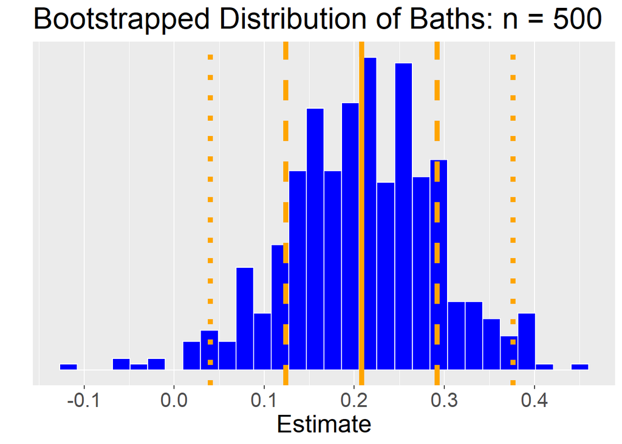

```r
df = data.frame(baths = hold[, 5])

ggplot(df, aes(x = baths)) +
  geom_histogram(fill = 'blue', color = 'white') +
  geom_vline(xintercept = m, size = 2, color = 'orange') +
  geom_vline(xintercept = c(m-s, m+s), size = 2, color = 'orange', linetype = 'dashed') +
  geom_vline(xintercept = c(m-2*s, m+2*s), size = 2, color = 'orange', linetype = 'dotted') +
  theme(text = element_text(size = 20)) +
  labs(x = 'Estimate', y = '', title = 'Bootstrapped Distribution of Baths: n = 500') +
  scale_y_continuous(breaks = NULL)
```

We have plotted some standard deviation lines, where the dashed is one standard deviation from the mean and the dotted is two standard deviations out. Wait, what p-values do these correspond to again?

# 2 AB Testing

Have you ever gone to an optometrist where you put your eyes up to a phoropter, and they ask you “number 1 or number 2, number 1 or number 2, number 1 or number 3” etc.? Well, that’s kind of what AB testing is like. This typically used in website development, where we want to see if one version of a website is more likely to have you click a link. They randomly show visitors website A or website B. Because we have random assignment, this allows us to obtain a causal effect.

We will use some data from [kaggle](https://www.kaggle.com/samtyagi/audacity-ab-testing). You may have heard of this company before… Let’s load in the data, do a small amount of EDA, and then perform some bootstrapping.

## 2.1 EDA

```r
ab = read.csv('C:/Users/johnj/Documents/Data/Applied ML ECON490/lecture data/homepage_actions.csv')
head(ab)
```

```
##                    timestamp     id      group action
## 1 2016-09-24 17:42:27.839496 804196 experiment   view
## 2 2016-09-24 19:19:03.542569 434745 experiment   view
## 3 2016-09-24 19:36:00.944135 507599 experiment   view
## 4 2016-09-24 19:59:02.646620 671993    control   view
## 5 2016-09-24 20:26:14.466886 536734 experiment   view
## 6 2016-09-24 20:32:25.712659 681598 experiment   view
```

```r
table(ab$group)
```

```
##
##    control experiment
##       4264       3924
```

```r
table(ab$group, ab$action)
```

```
##
##              click view
##   control      932 3332
##   experiment   928 2996
```

It looks like we have slightly more in the control group than the treatment group, but that is okay. Just a simple table makes it look like the treatment group may have had relatively more clicks in percentage terms.

Before we get into the bootstrapping, let me show you how to make use of the date information.

```r
library(lubridate)
ab$datetime = ymd_hms(ab$timestamp)
summary(ab$datetime)
```

```
##                  Min.               1st Qu.                Median
## "2016-09-24 17:42:27" "2016-10-23 07:42:49" "2016-11-22 11:40:49"
##                  Mean               3rd Qu.                  Max.
## "2016-11-22 02:03:51" "2016-12-21 11:47:10" "2017-01-18 10:24:08"
```

While we aren’t going to use this information in this lecture, we *could* use it to give us more information. Perhaps clicking habits differ by time of day (morning, lunchtime, evening, etc.), or day of the week, or time of the year (winter holidays, etc.).

To get the day of the week:

```r
weekdays(ab$datetime) %>% table
```

```
## .
##    Friday    Monday  Saturday    Sunday  Thursday   Tuesday Wednesday
##      1157      1202      1151      1144      1111      1246      1177
```

## 2.2 Bootstrapping

Without further ado, let’s get into it.

```r
# Standard AB testing
prop.test(c(932, 928), c(4264, 3924))
```

```
##
##  2-sample test for equality of proportions with continuity correction
##
## data:  c(932, 928) out of c(4264, 3924)
## X-squared = 3.6362, df = 1, p-value = 0.05654
## alternative hypothesis: two.sided
## 95 percent confidence interval:
##  -0.0363474612  0.0005089306
## sample estimates:
##    prop 1    prop 2
## 0.2185741 0.2364934
```

```r
# Where did I get these numbers from? Why did I put them in in these arguments?
```

We can also get a similar result using OLS. Remember, we are interested in the coefficient, not the predicted value. Here we are running an LPM.

```r
df = data.frame(click = (ab$action == 'click'), treatment = (ab$group == 'experiment'))

lm(click ~ treatment, data = df) %>% summary
```

```
##
## Call:
## lm(formula = click ~ treatment, data = df)
##
## Residuals:
##     Min      1Q  Median      3Q     Max
## -0.2365 -0.2365 -0.2186 -0.2186  0.7814
##
## Coefficients:
##               Estimate Std. Error t value Pr(>|t|)
## (Intercept)   0.218574   0.006416  34.068   <2e-16 ***
## treatmentTRUE 0.017919   0.009268   1.933   0.0532 .
## ---
## Signif. codes:  0 '***' 0.001 '**' 0.01 '*' 0.05 '.' 0.1 ' ' 1
##
## Residual standard error: 0.419 on 8186 degrees of freedom
## Multiple R-squared:  0.0004565,  Adjusted R-squared:  0.0003344
## F-statistic: 3.738 on 1 and 8186 DF,  p-value: 0.05321
```

Now we can bootstrap

```r
iterations = 500
hold = matrix(NaN, nrow = iterations)

n = dim(df)[1]
index = 1:n

for(i in 1:iterations){
  hold[i] = coef(lm(click ~ treatment, df, subset = sample(index, n, replace = T)))[2]
}

mean(hold)
```

```
## [1] 0.01728225
```

```r
sd(hold)
```

```
## [1] 0.009392497
```

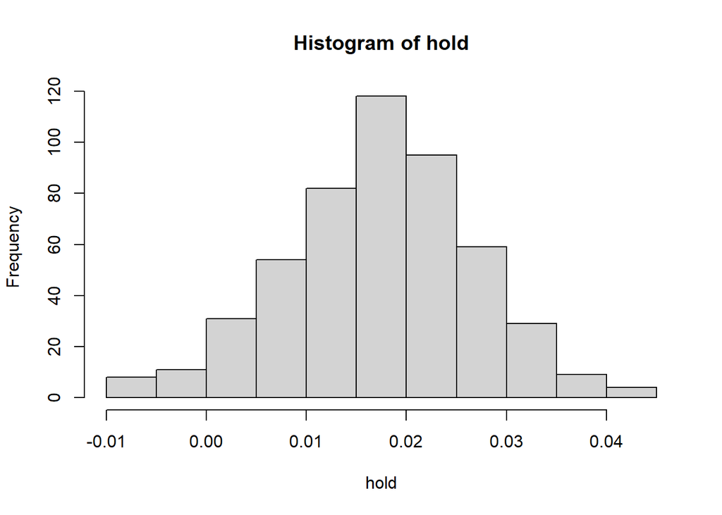

```r
hist(hold)
```

Just using a lazy `hist()` plot shows us that this coefficient is likely positive. Again, it is up to us to determine if this statistical significance is economically significant.